# Plant functional group composition and vegetation structure at CGREC

DAM

2021-12-03

# Key take-aways

# Plant functional group composition & vegetation structure

## Univariate trends–year by year

Tracking each response variable by treatment over the time period of the study.

### Smooth brome and Kentucky bluegrass

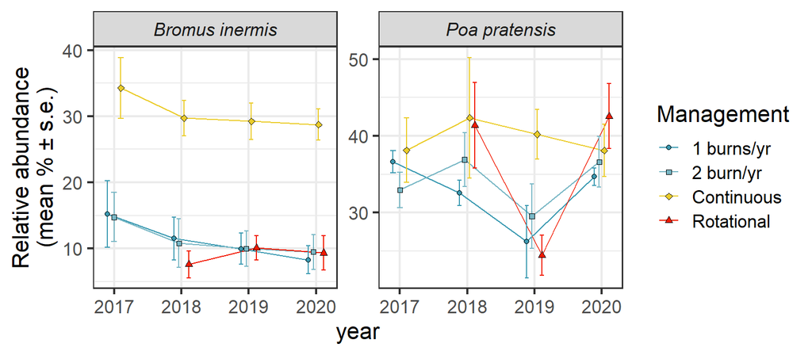

### Plant functional groups

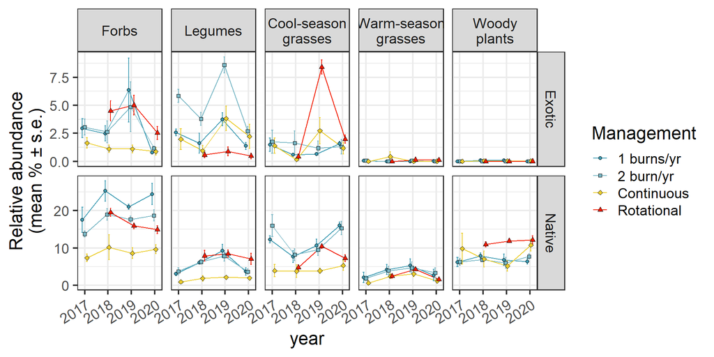

Native forbs and legumes were markedly lower in the Refuge than other management types, which were not terribly different from each other outside of the Refuge. The Wagon Wheel was consistently higher in native woody plants.

Few functional groups changed over the course of the study period. 2019-2020 changes seem isolated and are likely attributable to precipitation (overall lower productivity in 2020).

### Vegetation structure

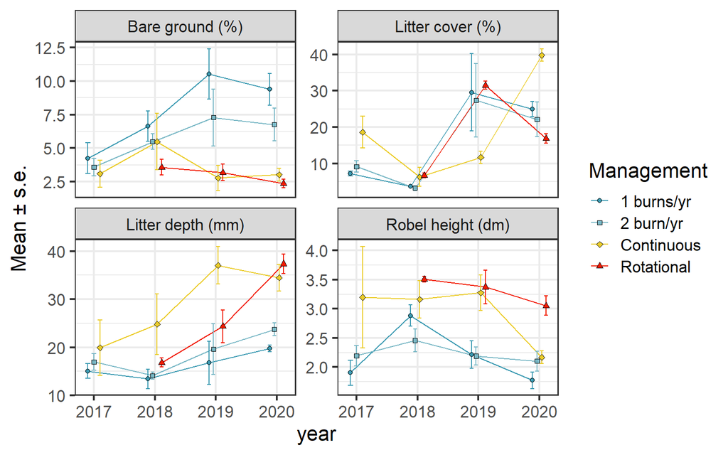

Increases in both litter and bare ground on PBG pastures is only possible with patchy fire, and can be interpreted as a treatment effect. Likewise, increasing litter cover & depth on the Refuge is an expected result, and probably for rotational pastures, as well.

## Changes over study period

Comparing final to initial values for each measured variable. Not sure how insightful these data are, given the influence of the 2020 drought. Hard to attribute any reductions, especially, to management.

### Smooth brome and Kentucky bluegrass

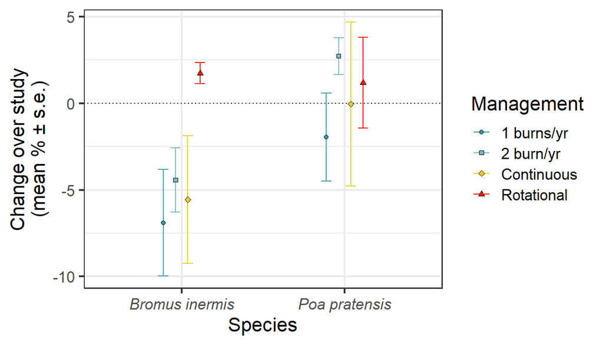

### Plant functional groups

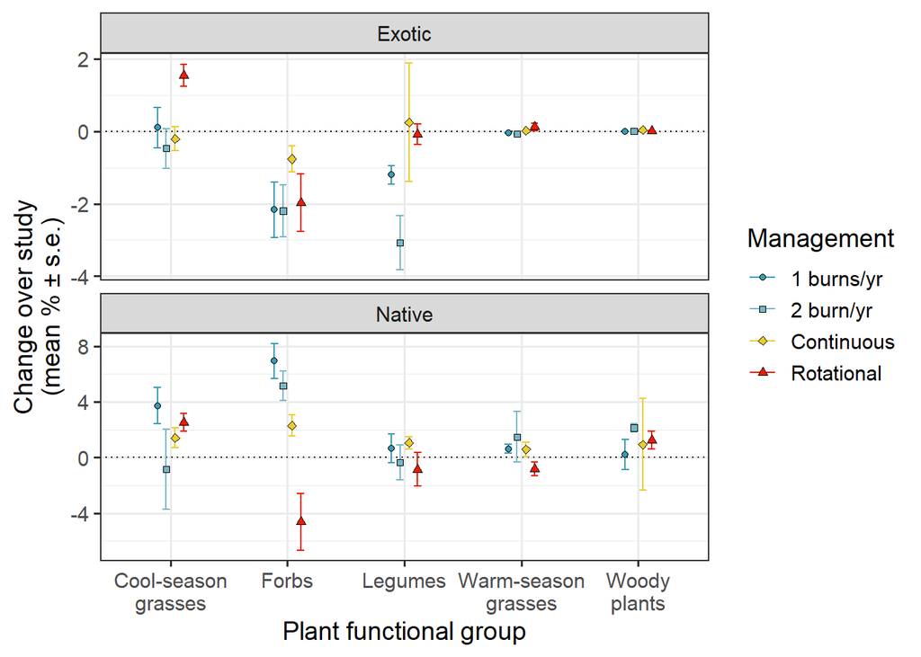

### Vegetation structure

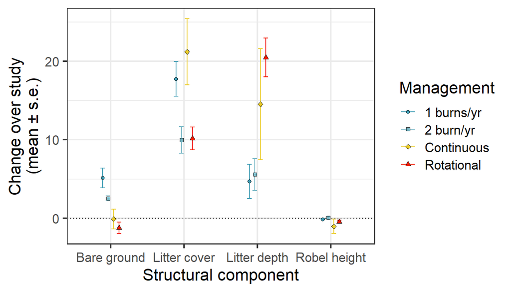

## Multivariate analyses

### Community dissimilarity

*Ordination results.–* Very slight changes are apparent among groups and over time in ordination space. Continuously-grazed pastures appear the most widely distributed at the beginning of the study, with several pastures associated with Native Woody Plants; the group contracts in the final period of the study. Unburned treatments (rotationally-grazed and continuously-grazed pastures) converge in ordination space, while both PBG treatments appear similar to each other in both timesteps and appear to move along a gradient towards grater native plant groups.

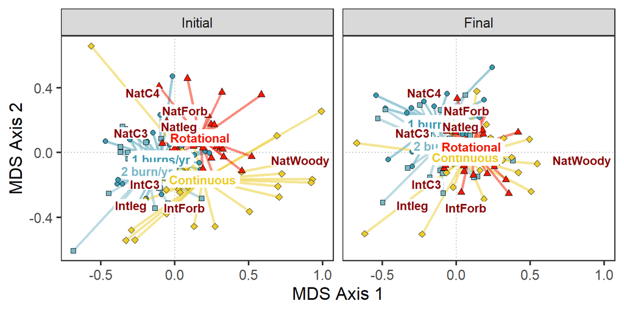

By the final year, plant functional group composition in PBG treatments had diverged (1 burn/yr vs. 2 burns/yr, P = 0.03). Composition in both PBG treatments changed over the course of the study (1 burn/yr, P = 0.03; 2 burns/yr, P = 0.03).

But composition of continuously-grazed pastures was no different than when the study started (P = 0.16) and was not different from the final composition of rotationally-grazed pastures, either (P = 0.27). Over the course of the study, composition of continuously-grazed pastures remained different than both PBG treatments (1 burn/yr, P = 0.03; 2 burns/yr, P = 0.03).

### Trajectory analysis

Arrows show how pasture centroids moved in ordination space from initial to final. Only PBG pastures moved consistently within treatment groups; this movement was away from introduced plant groups and towards native groups. General trend for Refuge pastures to increase towards native groups, as well, but to a lesser extent, consistent with univariate trends.

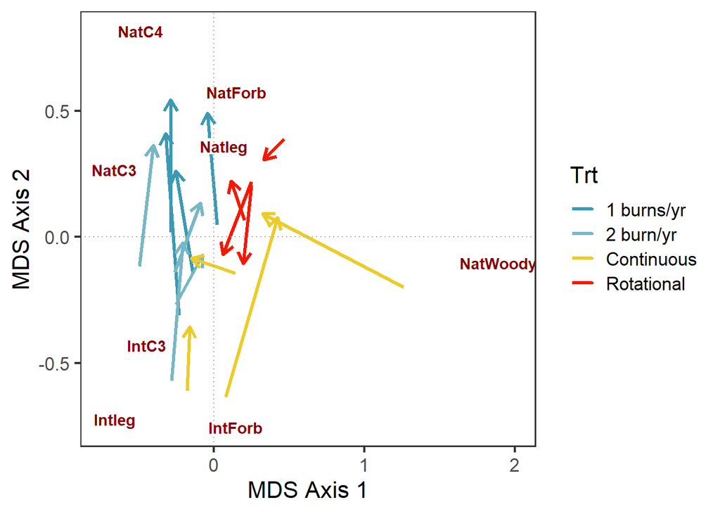

### Beta diversity

Beta diversity is a measure of the area a group occupies in ordination space and can be interpreted as vegetation heterogeneity within groups. Management practices meant to increase spatial heterogeneity should increase beta diversity, while practices meant to reduce spatial heterogeneity should also show lower beta diversity (tigher groups in ordination space).

Little effect was apparent over the course of the CGREC trials. Pastures at the Refuge started at relatively high spatial heterogeneity, which fell in line with other pastures following four years of continuous grazing.

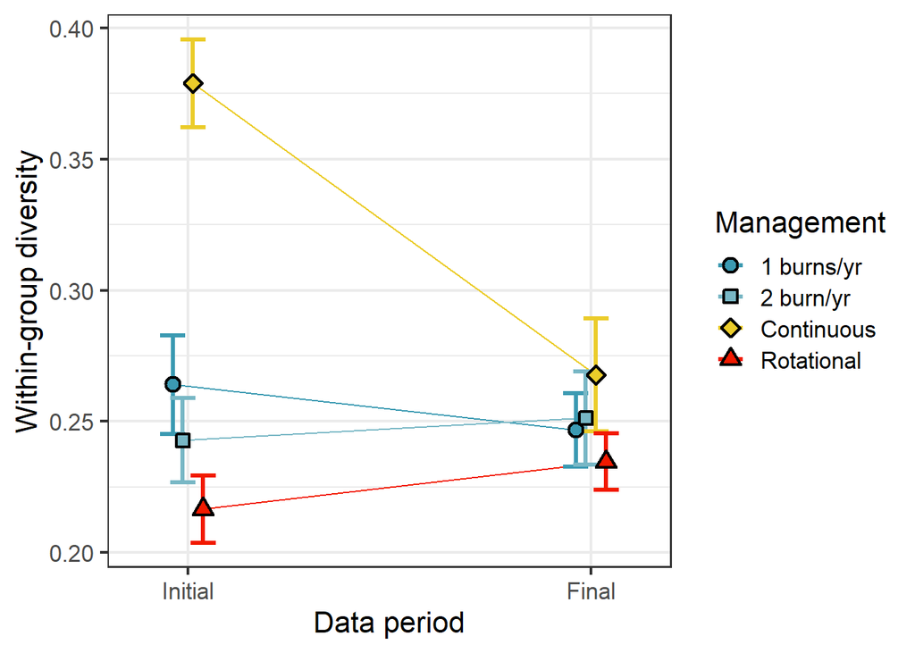

# Spatial heterogeneity

In this instance, *spatial heterogeneity* is defined as **patch contrast**–*the degree of difference among patches for several vegetation structure variables*. Patch contrast is measured as the amount of variance attributable to the patch term in a random-effect linear regression model fit for each response variable.

Spatial heterogeneity tended to be greatest among PBG pastures with a single, 40-ac burn each spring. Lowest heterogeneity tended to be among PBG pastures in which two burns were planned each year, but summer fires often did not occur. Continuously-grazed pastures without fire tended to have low heterogeneity, while rotationally-grazed pastures generally increased in heterogeneity since the initiation of the treatment.

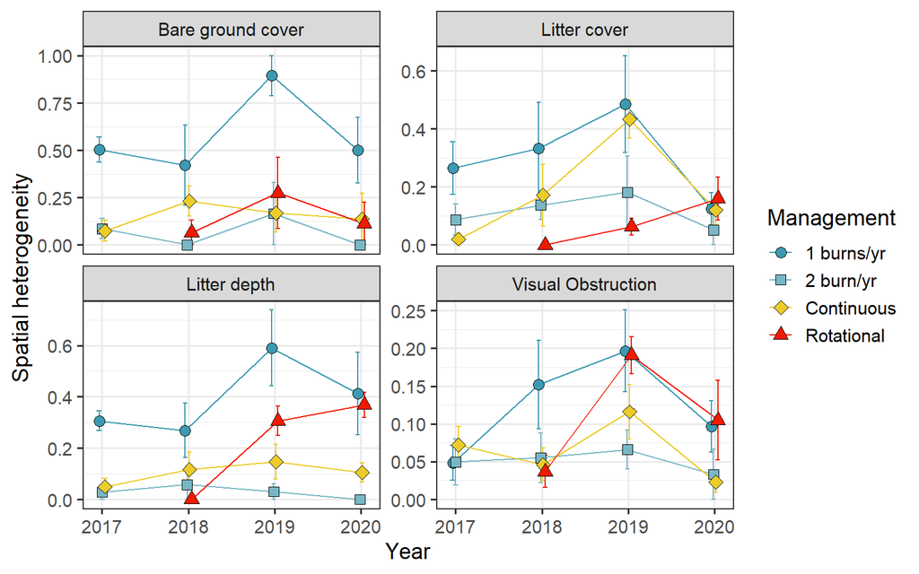